# STAT/MATH 495: Problem Set 07

Tim Lee

2017-10-24

Information on the competition can be found [here](https://www.kaggle.com/c/GiveMeSomeCredit/data).

# Collaboration

Please indicate who you collaborated with on this assignment: Pei Gong

# Build binary classifier

Build the binary classifier based on a single predictor variable: `DebtRatio`, `age`, or `MonthlyIncome`. Justify this choice.

## Exploratory Analysis

- I initially tried doing exploratory analysis with faceting the plots into if there was a `Serious Delinquency in 2 Years`. However, given the size of the dataset, ggplot was sluggish. Thus, while I have the code included, I decided not to run it in order to focus on other parts of the analysis.
- A more fruitful analysis on the best single predictor would be to see the Area Under the Curve (AUC) of a Receiver Operating Characteristic (ROC) Curve.

```r
# Debt Ratio
ggplot(data = train, aes(x = DebtRatio)) +
  geom_histogram(binwidth = 2) +
  facet_grid(SeriousDlqin2yrs ~ .) +
  coord_cartesian(xlim = c(0, 50)) +
  labs(x = "Debt Ratio", y = "Count", title = "Serious Delinquency in 2 Years")

# Age
ggplot(data = train, aes(x = age)) +
  geom_histogram(binwidth = 2) +
  facet_grid(SeriousDlqin2yrs ~ .) +
  coord_cartesian(xlim = c(0, 50)) +
  labs(x = "Debt Ratio", y = "Count", title = "Serious Delinquency in 2 Years")

# Monthly Income
ggplot(data = train, aes(x = MonthlyIncome)) +
  geom_histogram(binwidth = 2) +
  facet_grid(SeriousDlqin2yrs ~ .) +
  coord_cartesian(xlim = c(0, 50)) +
  labs(x = "Debt Ratio", y = "Count", title = "Serious Delinquency in 2 Years")
```

## Creating the Logistic Regressions

- I identified a logistic regression model (categorical outcome, quantitative predictors) for each of the three potential variables. This would allow me to see which option was the best with the AUC. Note that the p-values sometimes show as 0 in the table. This is due to rounding to 4 digits, and the actual p-value is simply very, very small (but not exactly at 0).

### Logistic Regression: Debt Ratio

| term | estimate | std.error | statistic | p.value | conf.low | conf.high |
| --- | --- | --- | --- | --- | --- | --- |
| (Intercept) | -2.622 | 0.0108 | -242.581 | 0 | -2.6432 | -2.601 |
| DebtRatio | 0.000 | 0.0000 | -4.225 | 0 | -0.0001 | 0.000 |

### Logistic Regression: Age

| term | estimate | std.error | statistic | p.value | conf.low | conf.high |
| --- | --- | --- | --- | --- | --- | --- |
| (Intercept) | -0.9902 | 0.0367 | -27.01 | 0 | -1.0621 | -0.9184 |
| age | -0.0334 | 0.0008 | -44.09 | 0 | -0.0349 | -0.0319 |

### Logistic Regression: Monthly Income

| term | estimate | std.error | statistic | p.value | conf.low | conf.high |
| --- | --- | --- | --- | --- | --- | --- |
| (Intercept) | -2.32 | 0.0201 | -115.61 | 0 | -2.3592 | -2.281 |
| MonthlyIncome | 0.00 | 0.0000 | -15.57 | 0 | -0.0001 | 0.000 |

## Making Predictions with AUC

- The Age variable has the highest AUC at around 0.64. This was better than the other options which did not reach about 0.6. `Monthly Income` was around 0.58, and `Debt Ratio` was around 0.48 (or 0.52 if reversed).

  |  | AUC |
  | --- | --- |
  | Monthly Income | 0.5760 |
  | Age | 0.6353 |
  | Debt Ratio | 0.4757 |

# ROC curve

Based on the ultimate classifier you choose, plot a corresponding ROC curve.

- I chose `age` as the ultimate classifer, since it had the highest AUC.

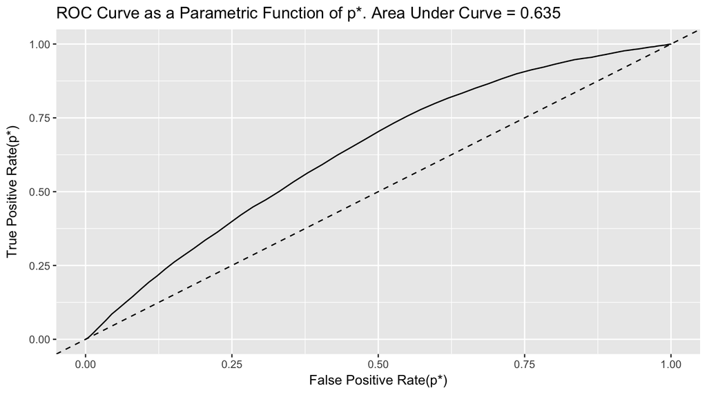

# ROC curve for random guessing

- Instead of using any predictor information as you did above, switch your predictions to random guesses and plot the resulting ROC curve.
- I shuffled with replacement the `SeriousDlqin2yrs` variable in order to break any relationship. As a result, it simulates random guessing and generates an AUC of around 0.501. This is generally consistent with the theoretical AUC value of 0.5 that represents random guessing.

```r
shuffled_SeriousDlq <- train["SeriousDlqin2yrs"] %>%
  sample_frac(size = 1, replace = TRUE)

train_random <- train %>%
  select(-SeriousDlqin2yrs) %>%
  bind_cols(., shuffled_SeriousDlq)

modelRandom <- glm(SeriousDlqin2yrs ~ age, data=train_random, family="binomial")
```

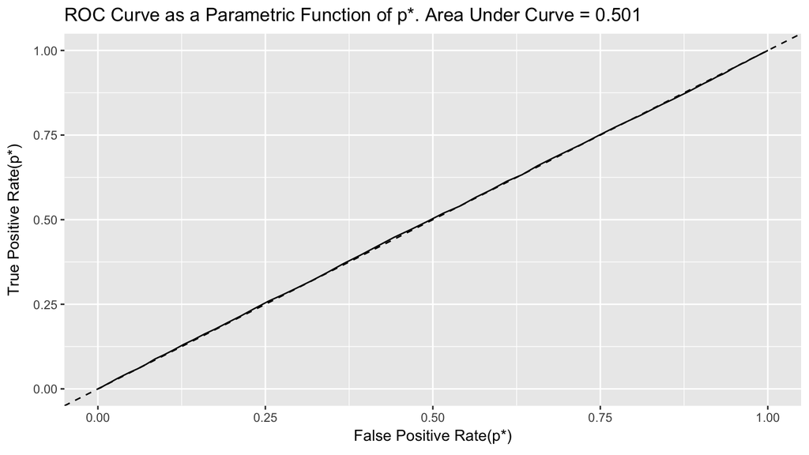

# Kaggle Prediction

```r
predictions <- modelAge %>%
  broom::augment(newdata=test) %>%
  mutate(p_hat = 1/(1 + exp(-.fitted))) %>%
  select(Probability = p_hat)

submission$Probability <- predictions$Probability
write.csv(submission, "submission.csv", row.names=FALSE)
```